# Sensitivity analysis: cases without comorbidity

Noemi Nicole Piga

23 August, 2024

```r
#library reticulate to be able to add chunks in another language
library(reticulate)
library(kableExtra)
#To run this .rmd file in a terminal being in the project folder:
#export PATH=${PATH}:/cm/shared/apps/R/deps/rstudio/bin/pandoc
#file="./src/report/Sensitivity_NoComorbidity.Rmd"
#module unload R/4.2.1
#module load R
#Rscript -e 'rmarkdown::render("'$file'")'
```

# Rationale

In the discovery cases definition, I included individuals with death/hospitalisation for asthma who also present a diagnosis for comorbidities; Comorbidities are defined as COPD and/or emphysema/chronic bronchitis.  
Among the 7,681 cases, I had included 1,488 with either death/hospitalisation with also a diagnosis for comorbidities. This represents a modest percentage of our cases (19.37%). We checked some physiological parameters including fev1 (% predicted), fev1/fvc, and BMI comparing cases with comorbidities (1,488) and without comorbidities (6,193): the cases with comorbidities showed lower respiratory capacity and higher BMI.  
Therefore, based on teh difference in physiological features, we decided to run a sensitivity analysis: we excluded the cases with comorbidities and we wanted to assess if the associated variants showed the same direction of effect of the discovery analysis.

# Analysis

We performed a GWAS analysis using REGENIE (v3.2.1) with 6,193 cases-no comorbidity- and 38,405 controls. The number of controls is the same as in the discovery analysis (ratio case:control is 1:6, higher than the discovery which is 1:5). We then compared the results for the suggestive signals, looking at the p-value and effect size.

Code: tmp_manuscript/src/

```r
#!/usr/bin/env Rscript

#Rationale: Create phenotype-covariate file for the sensitivity analysis without cases with comorbidities

library(tidyverse)
library(dplyr)
library(data.table)

all <- read.table("/data/gen1/UKBiobank_500K/severe_asthma/Noemi_PhD/data/demo_EUR_pheno_cov_broadasthma.txt", header=T)
comorbid <- read.table("/data/gen1/UKBiobank_500K/severe_asthma/Noemi_PhD/data/eid_emphchronCOPD_union.txt")
# create variable ==1 if individual has comorbidities, else 0
all$comorbid <- ifelse(all$IID %in% comorbid$V1, 1, 0)
all <- all %>% mutate(broad_pheno_nocomob = ifelse(broad_pheno_1_5_ratio == 1 & comorbid == 1, NA,
broad_pheno_1_5_ratio))
summary(as.factor(all$broad_pheno_nocomob))

write.table(all,"/data/gen1/UKBiobank_500K/severe_asthma/Noemi_PhD/data/demo_EUR_pheno_cov_broadasthma_nocomob.txt",
row.names = FALSE, col.names = TRUE ,quote=FALSE, sep=" ", na = "NA")
```

Code: tmp_manuscript/src/Demographicscheck_cases_with_comorbidities.R

```r
#!/usr/bin/env Rscript

#Rationale: check lung function, BMI of cases with hesin/death with comorbidities and cases with hesin/death without comorbidities.


library(tidyverse)
library(dplyr)
library(data.table)

all <- read.table("/data/gen1/UKBiobank_500K/severe_asthma/Noemi_PhD/data/demo_EUR_pheno_cov_broadasthma.txt", header=T)

all_asthma <- read.table("/data/gen1/UKBiobank_500K/severe_asthma/Noemi_PhD/data/Eid_intersection_asthma_diagnosis_ATLEAST_1_evidence.txt")

# create variable == 1 if individual is in all comer asthma group, else 0
all$allcomer <- ifelse(all$IID %in% all_asthma$V1, 1, 0)

comorbid <- read.table("/data/gen1/UKBiobank_500K/severe_asthma/Noemi_PhD/data/eid_emphchronCOPD_union.txt")
# create variable ==1 if individual has comorbidities, else 0
all$comorbid <- ifelse(all$IID %in% comorbid$V1, 1, 0)

all$eid <- as.factor(all$eid)

#Lung function from Kath file:
bridge_app648_8389 <- fread("/data/gen1/UKBiobank/application_648/mapping_to_app8389.txt",header=T)
bridge_app648_8389$app8389 <- as.character(bridge_app648_8389$app8389)
bridge_app648_8389$app648 <- as.character(bridge_app648_8389$app648)
#awk '{print $1, $52}' /data/gen1/UKBiobank_500K/severe_asthma/data/ukbiobank_master_app56607.sample \
#    > /data/gen1/UKBiobank_500K/severe_asthma/data/bridge_app648_56607
bridge_app648_56607 <- fread("/data/gen1/UKBiobank_500K/severe_asthma/data/bridge_app648_56607",sep=" ",header=T)
colnames(bridge_app648_56607) <- c("app648","app56607")
bridge_app648_56607$app56607 <- as.character(bridge_app648_56607$app56607)
bridge_app648_56607$app648 <- as.character(bridge_app648_56607$app648)
bridge_648_8389_56607 <- inner_join(bridge_app648_8389,bridge_app648_56607,by="app648")

perc_pred_fev1_kath <- fread("/data/gen1/UKBiobank_500K/severe_asthma/data/percent_pred_fev1.txt",header=T)
fev1_fvc_kath <- fread("/data/gen1/UKBiobank_500K/severe_asthma/data/ff.txt",header=T)
LF_kath <- inner_join(perc_pred_fev1_kath,fev1_fvc_kath,by="ID_1") %>% rename(app648=ID_1)
LF_kath$app648 <- as.character(LF_kath$app648)
LF_kath_app56607 <- left_join(LF_kath, bridge_648_8389_56607, by="app648") %>% select(app56607,fev1_perc_pred,ff.best) %>% rename(eid=app56607)

all_LF_kath <- left_join(all,LF_kath_app56607,by="eid")

#summarising command and comparision between different case/comorbidity status:

print("FEV1")
all_LF_kath %>% group_by(broad_pheno_1_5_ratio,pheno_1_5_ratio,comorbid) %>% dplyr::summarize(fev1 = mean(fev1_perc_pred, na.rm=TRUE))

print("FEV1/FVC")
all_LF_kath %>% group_by(cases_broad,pheno_1_5_ratio,comorbid) %>% dplyr::summarize(ratio_fev1_fvc = mean(ff.best, na.rm=TRUE))

print("BMI")
all_LF_kath %>% group_by(cases_broad,pheno_1_5_ratio,comorbid) %>% dplyr::summarize(BMI = mean(BMI, na.rm=TRUE))

print("sex")
all_LF_kath %>% group_by(cases_broad,pheno_1_5_ratio,comorbid) %>% dplyr::summarize(sex = mean(genetic_sex, na.rm=TRUE))
```

Code: tmp_manuscript/src/plink_QC_eur.sh

```r
#!/bin/bash

#SBATCH --job-name=plink_QC_eur
#SBATCH --output=/scratch/gen1/nnp5/sensitivity_comorb_tmp_data/logerror/%x-%j.out
#SBATCH --time=1:0:0
#SBATCH --mem=500gb
#SBATCH --account=gen1
#SBATCH --export=NONE


PATH_DATA="/data/gen1/UKBiobank_500K/severe_asthma/Noemi_PhD/data"
work_dir="/home/n/nnp5/PhD/PhD_project/tmp_manuscript"
geno_dir="/data/ukb/genotyped"
scratch_dir="/scratch/gen1/nnp5/sensitivity_comorb_tmp_data"

#mkdir /scratch/gen1/nnp5/sensitivity_comorb_tmp_data

#to create list of eur ids
#awk {'print $1, $2'} ${PATH_DATA}/demo_EUR_pheno_cov_broadasthma.txt | tail -n +2 > ${scratch_dir}/ukb_eur_ids

#cp from /rfs to my home the .fam
#cp /rfs/TobinGroup/data/UKBiobank/application_56607/ukb56607_cal_chr1_v2_s488239.fam ${work_dir}/

#rm ${work_dir}/list_plink_files
#for chr in {2..22}
#do echo "${geno_dir}/ukb_cal_chr${chr}_v2.bed \
#     ${geno_dir}/ukb_cal_chr${chr}_v2.bim \
#     ${work_dir}/ukb56607_cal_chr1_v2_s488239.fam" >> ${work_dir}/list_plink_files
#done

#module load gcc/12.3.0-yxgv2bl
#module load plink

#plink --bed ${geno_dir}/ukb_cal_chr1_v2.bed \
#   --bim ${geno_dir}/ukb_cal_chr1_v2.bim \
#   --fam ${work_dir}/ukb56607_cal_chr1_v2_s488239.fam \
#   --merge-list ${work_dir}/list_plink_files \
#   --make-bed --out ${scratch_dir}/ukb_cal_allchr_v2

#&&

awk '{print $1, $1}' /home/n/nnp5/UKBiobank_datafields/data/Eid_withdrawn_participants_upFeb2022.txt \
    > ${scratch_dir}/ukb_withdrawns_ids &&

module load plink2
plink2 --bfile ${scratch_dir}/ukb_cal_allchr_v2 \
    --maf 0.01 --mac 100 --geno 0.1 --hwe 1e-15 \
    --keep ${scratch_dir}/ukb_eur_ids \
    --remove ${scratch_dir}/ukb_withdrawns_ids \
    --mind 0.1 \
    --write-snplist --write-samples --no-id-header \
    --out ${scratch_dir}/ukb_cal_allchr_eur_qc &&

#cp ${scratch_dir}/ukb_cal_allchr_eur_qc.id ${work_dir}
```

Code: tmp_manuscript/src/run_regenie_step1.sh

```r
#!/bin/bash

#SBATCH --job-name=regenie1
#SBATCH --output=/scratch/gen1/nnp5/sensitivity_comorb_tmp_data/logerror/%x-%j.out
#SBATCH --time=15:0:0
#SBATCH --mem=200gb
#SBATCH --account=gen1
#SBATCH --export=NONE
#SBATCH --nodes=1
#SBATCH --ntasks=1
#SBATCH --cpus-per-task=4


PATH_DATA="/data/gen1/UKBiobank_500K/severe_asthma/Noemi_PhD/data"
work_dir="/home/n/nnp5/PhD/PhD_project/tmp_manuscript"
geno_dir="/data/ukb/genotyped"
scratch_dir="/scratch/gen1/nnp5/sensitivity_comorb_tmp_data"

OUT_DIR="/home/n/nnp5/PhD/PhD_project/tmp_manuscript/output"
pheno="broad_pheno_nocomob"

/home/n/nnp5/software/regenie_v3/regenie_v3.2.1.gz_x86_64_Centos7_mkl \
  --step 1 \
  --bed ${scratch_dir}/ukb_cal_allchr_v2 \
  --extract ${scratch_dir}/ukb_cal_allchr_eur_qc.snplist \
  --keep ${scratch_dir}/ukb_cal_allchr_eur_qc.id \
  --phenoFile ${PATH_DATA}/demo_EUR_pheno_cov_broadasthma_nocomob.txt \
  --phenoCol ${pheno} \
  --covarFile ${PATH_DATA}/demo_EUR_pheno_cov_broadasthma_nocomob.txt \
  --covarColList age_at_recruitment,age2,PC1,PC2,PC3,PC4,PC5,PC6,PC7,PC8,PC9,PC10,genetic_sex \
  --bt \
  --bsize 1000 \
  --loocv \
  --threads 4 \
  --gz \
  --out ${OUT_DIR}/${pheno}.regenie.step1
```

Code: tmp_manuscript/src/run_regenie_step2.sh

```r
#!/bin/bash

#SBATCH --output=/scratch/gen1/nnp5/sensitivity_comorb_tmp_data/logerror/%x-%j.out
#SBATCH --time=15:0:0
#SBATCH --mem=200gb
#SBATCH --account=gen1
#SBATCH --export=NONE
#SBATCH --nodes=1
#SBATCH --ntasks-per-node=1
#SBATCH --cpus-per-task=4
#SBATCH --array=1-22

#run as: sbatch --array=1-22 src/run_regenie_step2.sh
chr=$SLURM_ARRAY_TASK_ID
PATH_DATA="/data/gen1/UKBiobank_500K/severe_asthma/Noemi_PhD/data"
work_dir="/home/n/nnp5/PhD/PhD_project/tmp_manuscript"
geno_dir="/data/ukb/genotyped"
scratch_dir="/scratch/gen1/nnp5/sensitivity_comorb_tmp_data"
sample_DIR="/data/gen1/UKBiobank_500K/severe_asthma/data"
OUT_DIR="/home/n/nnp5/PhD/PhD_project/tmp_manuscript/output"
pheno="broad_pheno_nocomob"

/home/n/nnp5/software/regenie_v3/regenie_v3.2.1.gz_x86_64_Centos7_mkl \
  --step 2 \
  --bgen /data/ukb/imputed_v3/ukb_imp_chr${chr}_v3.bgen \
  --ref-first \
  --sample ${sample_DIR}/ukbiobank_app56607_for_regenie.sample \
  --keep ${scratch_dir}/ukb_cal_allchr_eur_qc.id \
  --phenoFile ${PATH_DATA}/demo_EUR_pheno_cov_broadasthma_nocomob.txt \
  --phenoCol ${pheno} \
  --covarFile ${PATH_DATA}/demo_EUR_pheno_cov_broadasthma_nocomob.txt \
  --covarColList age_at_recruitment,age2,PC1,PC2,PC3,PC4,PC5,PC6,PC7,PC8,PC9,PC10,genetic_sex \
  --bt \
  --gz \
  --threads 4 \
  --minMAC 10 \
  --minINFO 0.3 \
  --firth --approx --pThresh 0.01 \
  --pred ${OUT_DIR}/${pheno}.regenie.step1_pred.list \
  --bsize 1000 \
  --out ${OUT_DIR}/${pheno}.${chr}.regenie.step2
```

Code: tmp_manuscript/src/create_input_munge_summary_stats.sh

```r
#!/usr/bin/env Rscript

library(data.table)
library(tidyverse)

args = commandArgs(trailingOnly=TRUE)
df_file <- args[1]
pheno <- as.character(args[2])

df <- fread(df_file,header=F)

#CHROM GENPOS ID ALLELE0 ALLELE1 A1FREQ INFO N TEST BETA SE CHISQ LOG10P
#REGENIE: reference allele (allele 0), alternative allele (allele 1)
#REGENIE:  estimated effect sizes (for allele 1 on the original scale)

colnames(df) <- c("CHROM", "GENPOS", "ID", "ALLELE0", "ALLELE1", "A1FREQ", "INFO", "N","TEST", "BETA", "SE", "CHISQ", "LOG10P")
dfclean <- df %>% select(CHROM,ID,GENPOS,ALLELE1,ALLELE0,A1FREQ,LOG10P,BETA,SE)

dfclean$pval <- 10^(-dfclean$LOG10P)

#select column in order:
dfclean <- dfclean %>% select(ID,CHROM,GENPOS,ALLELE1,ALLELE0,BETA,SE,A1FREQ,pval)

#rename columns :
colnames(dfclean) <- c("snpid", "b37chr", "bp", "a1", "a2", "LOG_ODDS", "se", "eaf", "pval")
#save gwas all chr results:

#write.table(dfclean,paste0("output/",pheno,"_betase_input_mungestat"),quote=FALSE,sep="\t",row.names=FALSE)


#make sure eaf column is numeric:
dfclean$eaf <- as.numeric(dfclean$eaf)

#create MAF columns and filtered out for MAF >= 0.01:
dfclean <- dfclean %>% mutate(MAF = ifelse(dfclean$eaf <= 0.5, dfclean$eaf, 1 - dfclean$eaf))
dfclean_MAF001 <- dfclean %>% filter(MAF >= 0.01)

#save gaws results for variants with MAF >= 0.01:
write.table(dfclean_MAF001,paste0("output/maf001_",pheno,"_betase_input_mungestat"),quote=FALSE,sep="\t",row.names=FALSE)
```

Code: tmp_manuscript/src/postGWAS_analyses.sh

```r
#!/bin/bash

#SBATCH --output=/scratch/gen1/nnp5/sensitivity_comorb_tmp_data/logerror/%x-%j.out
#SBATCH --time=15:0:0
#SBATCH --mem=200gb
#SBATCH --account=gen1
#SBATCH --export=NONE
#SBATCH --nodes=1
#SBATCH --ntasks-per-node=1
#SBATCH --cpus-per-task=4

PATH_OUT="/home/n/nnp5/PhD/PhD_project/tmp_manuscript/output"
PHENO="broad_pheno_nocomob"

mkdir ${PATH_OUT}/allchr
GWAS="/home/n/nnp5/PhD/PhD_project/tmp_manuscript/output/allchr"

#merge all assoc file:
zcat ${PATH_OUT}/${PHENO}.1.regenie.step2_${PHENO}.regenie.gz | tail -n +2 | \
     awk -F " " '{print $1, $2, $3, $4, $5, $6, $7, $8, $9, $10, $11, $12, $13}' \
    > ${GWAS}/${PHENO}_allchr.assoc.txt

for i in {2..22}
    do zcat ${PATH_OUT}/${PHENO}.${i}.regenie.step2_${PHENO}.regenie.gz | \
    tail -n +2 | awk -F " " '{print $1, $2, $3, $4, $5, $6, $7, $8, $9, $10, $11, $12, $13}' \
    >> ${GWAS}/${PHENO}_allchr.assoc.txt
done


gzip ${GWAS}/${PHENO}_allchr.assoc.txt
cp ${GWAS}/${PHENO}_allchr.assoc.txt.gz /data/gen1/UKBiobank_500K/severe_asthma/Noemi_PhD/data/

#create input ldsc file both for all vars and maf >= 0.01.
module load R
chmod o+x src/create_input_munge_summary_stats.R
dos2unix src/create_input_munge_summary_stats.R
Rscript src/create_input_munge_summary_stats.R \
    ${GWAS}/${PHENO}_allchr.assoc.txt.gz \
    ${PHENO}

cp ${PATH_OUT}/maf001_broad_pheno_nocomob_betase_input_mungestat /data/gen1/UKBiobank_500K/severe_asthma/Noemi_PhD/data/

#LDSC interactively.
#The results are the same for set with all vars and fitlered maf 0.01., because LDSC uses only vars > 0.01. So run
#on the filtered set
cd /home/n/nnp5/software/ldsc
#to create the env:
#conda env create --file environment.yml
#source activate ldsc

tot_n=44598
PHENO="maf001_broad_pheno_nocomob"

awk '{print $1, $2, $3, $4, $5, $6, $7, $8, $9}' ${PATH_OUT}/${PHENO}_betase_input_mungestat \
    > ${PATH_OUT}/${PHENO}_betase_input_mungestat_clean

#interactively:
conda activate ldsc
/home/n/nnp5/software/ldsc/munge_sumstats.py \
--sumstats ${PATH_OUT}/${PHENO}_betase_input_mungestat_clean \
--N ${tot_n}   \
--out ${PATH_OUT}/${PHENO}_allchr_step2_regenie \
--merge-alleles /data/gen1/UKBiobank/Smoking/Meta_Analysis_AWI_UGR_UKBAFR/files/w_hm3.snplist \
--chunksize 500000

/home/n/nnp5/software/ldsc/ldsc.py \
--h2 ${PATH_OUT}/${PHENO}_allchr_step2_regenie.sumstats.gz \
--ref-ld-chr /data/gen1/reference/ldsc/eur_w_ld_chr/ \
--w-ld-chr /data/gen1/reference/ldsc/eur_w_ld_chr/ \
--out ${PATH_OUT}/${PHENO}_allchr_step2_regenie_h2

conda deactivate
cd /home/n/nnp5/PhD/PhD_project/tmp_manuscript/
cp ${PATH_OUT}/${PHENO}_allchr_step2_regenie_h2.log /data/gen1/UKBiobank_500K/severe_asthma/Noemi_PhD/data/

#Plots:
ldsc_intercept='1.02'

#run Manhattan, qqplot, lambda for vars with maf >= 0.01:
PHENO="maf001_broad_pheno_nocomob"
chmod o+x src/plot_functions.R
dos2unix src/plot_functions.R
chmod o+x src/REGENIE_plots.R
dos2unix src/REGENIE_plots.R
Rscript src/REGENIE_plots.R ${PATH_OUT}/${PHENO}_betase_input_mungestat ${PHENO} ${ldsc_intercept}


#Miami plot:
to find a new library as the 'hudson' do not work on R 4.3.1

#look at suggestive variants from discovery GWAS to see if they have similar effect size and same direction of effect:
PHENO="maf001_broad_pheno_nocomob"
awk '{print $1}' ${PATH_OUT}/maf001_pheno_1_5_ratio_sentinel_variants.txt | \
    grep -w -F -f - ${PATH_OUT}/${PHENO}_betase_input_mungestat > ${PATH_OUT}/${PHENO}_BTS45_sentinel_vars

#create OddsRatio and direction of effect using Create_oddsratio.R


#Compare broad_pheno suggestive variants with broad_pheno_nocomob: direction of effect
awk '{print $1}' /data/gen1/UKBiobank_500K/severe_asthma/Noemi_PhD/data/UKBiobank_severeasthma_sentinel_suggestive_to_replicate.txt | \
    grep -F -f - -w /data/gen1/UKBiobank_500K/severe_asthma/Noemi_PhD/data/maf001_broad_pheno_nocomob_betase_input_mungestat \
    > ${PATH_OUT}/maf001_broad_pheno_nocomob_for_sensitivity

chmod o+x src/sensitivity_check.R
dos2unix src/sensitivity_check.R
Rscript src/sensitivity_check.R /data/gen1/UKBiobank_500K/severe_asthma/Noemi_PhD/data/Disc_VS_Meta_sumstat_6cohorts.txt \
    ${PATH_OUT}/maf001_broad_pheno_nocomob_for_sensitivity \
    ${PATH_OUT}/sensitivity_nocomob_suggestive_discovery.txt

cp ${PATH_OUT}/sensitivity_nocomob_suggestive_discovery.txt /data/gen1/UKBiobank_500K/severe_asthma/Noemi_PhD/data/
```

Code: tmp_manuscript/src/plot_functions.R

```r
#Plot inflation plot with qqman package and qq() function.
plot.qqplot <- function(pval_vec,title){
           filename = paste0("output/Q-Q_plot_",title,".png")
           plot_title = paste0("Q-Q plot ",title)
           png(filename, width = 480, height = 480, units = "px", pointsize = 12, bg = "white")
               print(qq(pval_vec, main = plot_title, xlim = c(0,30), ylim = c(0,30), cex.axis = 1, cex = 1, las = 1)) #function from qqman library
               dev.off()
}

# Create a Manhattan plot from a data frame containing the results of
# a GEMMA association analysis.
plot.Manha <- function (dataset,test_type,title) {
          colnames(dataset) <- c("SNP","CHR","BP","P") #the Manhattan function needs this format
              filename <- paste0("output/Manhattan_plot_",title,".png")
              plot_title = paste0("Manhattan plot ",title)
          png(filename, width = 2700, height = 550, units = "px", pointsize = 12, bg = "white")
          manhattan(dataset, main = title, col = c("lightblue","blue3"), chrlabs = as.character(c(1:22)), ylim = c(0,30),
          cex = 1.5, cex.axis = 1.5, suggestiveline = F, genomewideline = F, cex.lab = 1.5)
          #function from qqman library
          abline(h=-log10(0.00000005),lty="dashed",col="black")
          abline(h=-log10(0.000005),lty="solid",col="black")
          dev.off()
}





#Estimate lambda using pval:
lambda_func <- function(pval,title){
        filename <- paste0("output/lambda_",title,".txt")
        pval <- qnorm(pval/2)
        lambda_frompval = round(median(pval^2,na.rm=T)/qchisq(0.5,df=1),2)
        write.table(lambda_frompval,filename,col.names="lambda",row.names=F)
        return
        lambda_frompval
}


# Create a simple Manhattan plot from a data frame containing the
# results of a GEMMA association analysis, in which p-values are
# plotted against base-pair positions (in Mb).
plot.region.pvalues <- function (gwscan, size = 1) {

  # Convert the p-values to the -log10 scale.
  gwscan <- transform(gwscan,p_lrt = -log10(p_lrt))

  # Convert the positions to the Megabase (Mb) scale.
  gwscan <- transform(gwscan,ps = ps/1e6)

  # Create a Manhattan plot.
  return(ggplot(gwscan,aes(x = ps,y = p_lrt)) +
         geom_point(color = "darkblue",size = size,shape = 20) +
         labs(x = "base-pair position (Mb)",y = "-log10 p-value") +
         theme_cowplot(font_size = 10) +
         theme(axis.line = element_blank()))
}
```

Code: tmp_manuscript/src/REGENIE_plots.R

```r
#!/usr/bin/env Rscript
library(qqman) #qq plot and manhattan plot
library(ggplot2)
library(data.table)
library(grid)
library(tidyverse)
#call the plot_functions.R for QQ-plot,Manhattan and lambda:
source("src/plot_functions.R")

args = commandArgs(TRUE)


#inputfile:
input_file = args[1] #input mungestat file
pheno = args[2]
ldsc_intercept = as.numeric(args[3])
#input
meta <- fread(input_file, header=T, fill=T)

title_plot <- paste0("GWAS_",pheno)


#QQ plot with qqman package: one genome-wide for each test-statistic p-val:
plot.qqplot(pval_vec = meta$pval, title= title_plot)


#Manhattan plot:
# require these columns: rs,chr,ps,pval
df <- meta %>% select(snpid,b37chr,bp,pval)
colnames(df) <- c("rs","chr","ps","pval")
df$chr <- as.numeric(df$chr)
df$ps <- as.numeric(df$ps)
plot.Manha(df, title = title_plot)
```

Code: tmp_manuscript/src/sensitivity_check.R

```r
#!/usr/bin/env Rscript


suppressMessages(library(tidyverse))
suppressMessages(library(data.table))

args = commandArgs(trailingOnly=TRUE)

#sumstat1_file = "/data/gen1/UKBiobank_500K/severe_asthma/Noemi_PhD/data/Disc_VS_Meta_sumstat_6cohorts.txt"
#sumstat2_file = "output/maf001_broad_pheno_nocomob_for_sensitivity"
#output_file = "output/sensitivity_nocomob_suggestive_discovery.txt"

sumstat1_file = args[1]
sumstat2_file = args[2]
output_file = args[3]

#input:
sumstat1 <- fread(sumstat1_file,header=T)
sumstat2 <- fread(sumstat2_file,header=T)

#create odds_ratio ci_lower ci_upper for no-comorbidity GWAS:
sumstat2$odds_ratio <- exp(sumstat2$LOG_ODDS)
sumstat2$ci_lower <- exp(sumstat2$LOG_ODDS - qnorm(0.975)*sumstat2$se)
sumstat2$ci_upper <- exp(sumstat2$LOG_ODDS + qnorm(0.975)*sumstat2$se)
#create unique column:
sumstat2$'OR_95_CI' <- paste0(format(round(sumstat2$odds_ratio,2),nsmall=2)," [",format(round(sumstat2$ci_lower,2),nsmall=2),"-",format(round(sumstat2$ci_upper,2),nsmall=2),"]")
#direction of effect:
sumstat2 <- sumstat2 %>% mutate(direction_of_effect=ifelse(sumstat2$LOG_ODDS > 0, "+","-"))

#check:
sumstat2 <- sumstat2 %>% rename(SNP_UKB=snpid, chr=b37chr, pos_b37=bp, EA=a1, NEA=a2)
colnames(sumstat2)[6:15] <- paste(colnames(sumstat2)[6:15], "no_comob", sep = "_")
check <- left_join(sumstat1, sumstat2, by = c("SNP_UKB","chr","pos_b37","EA","NEA"))
check$concordance_nocomob <- ifelse((check$odds_ratio > 0 & check$odds_ratio_no_comob > 0) | (check$odds_ratio < 0 & check$odds_ratio_no_comob < 0), "yes", "no")

write.table(check,output_file,sep="\t",quote=F,row.names=F)

png("output/sensitivity_nocomob_check_oddsratio.png")
plot(check$odds_ratio, check$odds_ratio_no_comob)
dev.off()
png("output/sensitivity_nocomob_check_pval.png")
plot(check$pval, check$pval_no_comob, xlim= c(0,0.0003), ylim=c(0,0.0003))
dev.off()
```

# Results

The GWAS analysis showed a LDSC intercept of 1.02 suggesting no further correction needed to the statistics.  
The sensitivity analysis results showed the same direction of effect of the discovery analysis. For some variants, the p-value is less significant.

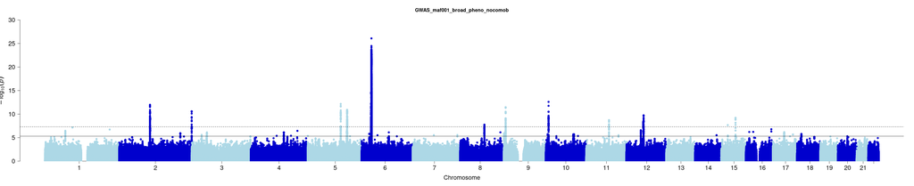

Manhattan Plot sensitivity analysis no-comorbidities.

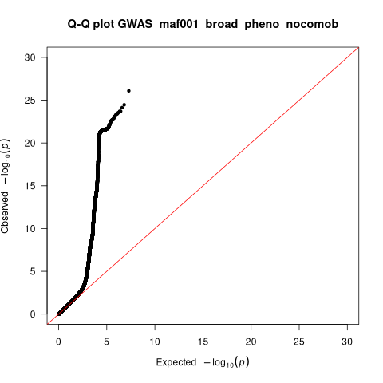

Q-Q Plot sensitivity analysis no-comorbidities.

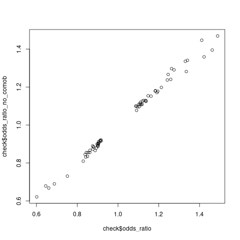

Odds ration plot.

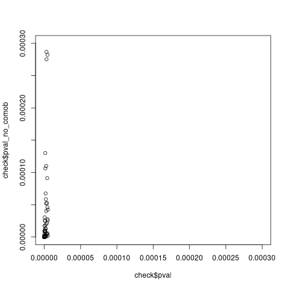

P-value plot.

| SNP_UKB | chr | pos_b37 | pos_b38 | EA | NEA | pval | pval_no_comob | OR_95_CI | OR_95_CI_no_comob | concordance_nocomob |
| --- | --- | --- | --- | --- | --- | --- | --- | --- | --- | --- |
| rs5004091 | 1 | 216909333 | 216735991 | A | T | 1.64e-07 | 1.93e-07 | 1.11 [1.07-1.15] | 1.12 [1.07-1.17] | yes |
| rs737148 | 2 | 43015119 | 42787979 | T | C | 8.27e-07 | 7.89e-06 | 1.11 [1.07-1.16] | 1.11 [1.06-1.16] | yes |
| rs12470864 | 2 | 102926362 | 102309902 | A | G | 7.55e-14 | 1.06e-12 | 1.15 [1.11-1.19] | 1.15 [1.11-1.20] | yes |
| 2:140312261_AT_A | 2 | 140312261 | 139554692 | A | AT | 5.66e-07 | 1.72e-05 | 0.91 [0.88-0.95] | 0.92 [0.88-0.95] | yes |
| 2:140312261_AT_A | 2 | 140312261 | 139554692 | A | AT | 5.66e-07 | 1.72e-05 | 0.91 [0.88-0.95] | 0.92 [0.88-0.95] | yes |
| rs78004582 | 2 | 178576703 | 177711975 | T | C | 1.60e-06 | 7.81e-06 | 1.33 [1.19-1.49] | 1.34 [1.18-1.51] | yes |
| rs3116499 | 2 | 204649276 | 203784553 | A | G | 1.45e-06 | 1.13e-06 | 0.90 [0.87-0.94] | 0.89 [0.85-0.93] | yes |
| rs578000716 | 2 | 216844193 | 215979470 | A | T | 4.41e-06 | 5.75e-06 | 1.25 [1.14-1.37] | 1.27 [1.15-1.40] | yes |
| rs75520741 | 2 | 234641604 | 233732958 | G | C | 2.41e-06 | 5.22e-05 | 1.21 [1.12-1.31] | 1.20 [1.10-1.31] | yes |
| rs6761047 | 2 | 242692858 | 241753443 | T | C | 4.18e-12 | 2.60e-11 | 0.86 [0.83-0.90] | 0.86 [0.82-0.90] | yes |
| rs35570272 | 3 | 33047662 | 33006170 | T | G | 3.16e-06 | 2.61e-06 | 1.09 [1.05-1.13] | 1.10 [1.06-1.14] | yes |
| rs762279794 | 3 | 48710839 | 48673406 | C | CA | 4.31e-06 | 4.61e-05 | 0.86 [0.81-0.92] | 0.87 [0.81-0.93] | yes |
| rs778801698 | 3 | 50024027 | 49986594 | C | CA | 1.93e-08 | 1.31e-06 | 1.11 [1.07-1.16] | 1.11 [1.06-1.15] | yes |
| rs112565872 | 3 | 196359973 | 196633102 | T | C | 3.22e-06 | 5.34e-06 | 0.84 [0.78-0.91] | 0.83 [0.77-0.90] | yes |
| rs75636118 | 4 | 86621713 | 85700560 | T | C | 6.86e-08 | 4.17e-06 | 1.26 [1.16-1.37] | 1.24 [1.13-1.36] | yes |
| 4:110706049_GA_G | 4 | 110706049 | 109784893 | G | GA | 2.83e-07 | 7.82e-07 | 0.90 [0.87-0.94] | 0.90 [0.86-0.94] | yes |
| rs78486128 | 5 | 14690667 | 14690558 | A | G | 6.13e-07 | 3.04e-05 | 1.20 [1.12-1.28] | 1.18 [1.09-1.27] | yes |
| rs1837253 | 5 | 110401872 | 111066174 | C | T | 1.25e-15 | 6.96e-13 | 1.18 [1.13-1.23] | 1.18 [1.13-1.23] | yes |
| rs3806932 | 5 | 110405675 | 111069977 | G | A | 1.03e-07 | 1.19e-06 | 0.91 [0.87-0.94] | 0.91 [0.87-0.94] | yes |
| rs2188962 | 5 | 131770805 | 132435113 | T | C | 6.88e-13 | 1.33e-11 | 0.88 [0.85-0.91] | 0.87 [0.84-0.91] | yes |
| rs848 | 5 | 131996500 | 132660808 | C | A | 3.96e-12 | 3.50e-10 | 0.85 [0.82-0.89] | 0.86 [0.81-0.90] | yes |
| rs2744254 | 6 | 25266803 | 25266575 | G | T | 3.14e-07 | 1.48e-06 | 1.11 [1.07-1.15] | 1.11 [1.06-1.16] | yes |
| rs2523572 | 6 | 31329494 | 31361717 | T | C | 2.12e-18 | 2.57e-15 | 1.18 [1.14-1.23] | 1.18 [1.13-1.23] | yes |
| rs6462 | 6 | 32006597 | 32038820 | T | C | 5.03e-10 | 6.14e-08 | 1.14 [1.09-1.18] | 1.13 [1.08-1.18] | yes |
| rs9271365 | 6 | 32586794 | 32619017 | G | T | 9.20e-33 | 8.16e-27 | 1.24 [1.20-1.29] | 1.24 [1.19-1.29] | yes |
| rs148639908 | 6 | 90963614 | 90253895 | AT | A | 1.30e-07 | 9.46e-06 | 0.90 [0.87-0.94] | 0.91 [0.88-0.95] | yes |
| rs883719 | 7 | 6656204 | 6616573 | G | A | 1.08e-06 | 2.52e-05 | 1.14 [1.08-1.20] | 1.13 [1.07-1.19] | yes |
| rs76260102 | 7 | 149733155 | 150036066 | T | C | 1.22e-06 | 2.80e-06 | 1.27 [1.16-1.40] | 1.29 [1.16-1.43] | yes |
| rs6557746 | 8 | 24285553 | 24428040 | C | A | 2.05e-06 | 1.25e-05 | 0.90 [0.87-0.94] | 0.90 [0.86-0.94] | yes |
| rs62512193 | 8 | 70564070 | 69651835 | G | A | 4.87e-06 | 4.26e-05 | 0.90 [0.86-0.94] | 0.90 [0.86-0.95] | yes |
| rs7824394 | 8 | 81292599 | 80380364 | C | A | 1.39e-08 | 1.75e-08 | 0.90 [0.87-0.93] | 0.89 [0.86-0.93] | yes |
| rs71576013 | 8 | 134855565 | 133843322 | C | G | 2.62e-06 | 7.48e-07 | 0.89 [0.85-0.94] | 0.88 [0.84-0.93] | yes |
| rs10117067 | 9 | 4145624 | 4145624 | C | T | 3.96e-07 | 7.70e-07 | 1.10 [1.06-1.14] | 1.11 [1.06-1.16] | yes |
| rs992969 | 9 | 6209697 | 6209697 | G | A | 2.83e-16 | 3.77e-12 | 0.84 [0.81-0.88] | 0.86 [0.82-0.89] | yes |
| rs11816044 | 10 | 6074082 | 6032119 | A | G | 1.93e-07 | 1.82e-06 | 0.90 [0.87-0.94] | 0.90 [0.87-0.94] | yes |
| rs11256010 | 10 | 9035254 | 8993291 | C | T | 2.62e-06 | 1.10e-04 | 0.65 [0.53-0.78] | 0.68 [0.55-0.83] | yes |
| rs201499805 | 10 | 9042744 | 9000781 | C | CT | 8.79e-17 | 2.52e-13 | 0.84 [0.80-0.87] | 0.85 [0.81-0.88] | yes |
| rs1444789 | 10 | 9064361 | 9022398 | C | T | 1.17e-14 | 2.25e-10 | 1.19 [1.14-1.24] | 1.17 [1.12-1.23] | yes |
| rs7918084 | 10 | 94429467 | 92669710 | T | C | 4.94e-06 | 1.93e-06 | 1.09 [1.05-1.13] | 1.10 [1.06-1.14] | yes |
| rs17750886 | 10 | 105927460 | 104167702 | T | C | 2.74e-06 | 4.02e-05 | 0.88 [0.83-0.93] | 0.88 [0.83-0.94] | yes |
| rs140331704 | 10 | 107781145 | 106021387 | A | G | 3.55e-06 | 4.47e-06 | 1.41 [1.22-1.63] | 1.45 [1.24-1.68] | yes |
| rs174583 | 11 | 61609750 | 61842278 | T | C | 4.36e-06 | 2.75e-05 | 0.92 [0.88-0.95] | 0.92 [0.88-0.95] | yes |
| rs10160518 | 11 | 76296671 | 76585627 | G | A | 4.29e-10 | 1.97e-09 | 1.12 [1.08-1.16] | 1.13 [1.08-1.17] | yes |
| rs71488266 | 11 | 107540609 | 107669883 | A | G | 1.38e-06 | 1.30e-04 | 1.46 [1.26-1.70] | 1.39 [1.18-1.65] | yes |
| rs73107993 | 12 | 48195873 | 47802090 | T | C | 1.10e-06 | 2.71e-07 | 0.90 [0.86-0.94] | 0.89 [0.85-0.93] | yes |
| rs705705 | 12 | 56435504 | 56041720 | C | G | 3.85e-10 | 4.69e-09 | 1.13 [1.09-1.17] | 1.13 [1.08-1.18] | yes |
| rs3024971 | 12 | 57493727 | 57099944 | G | T | 5.92e-10 | 1.82e-10 | 0.83 [0.78-0.88] | 0.81 [0.76-0.86] | yes |
| 12:94558437_GCACACACACA_G | 12 | 94558437 | 94164661 | G | GCACACACACA | 1.85e-06 | 6.74e-05 | 1.14 [1.08-1.20] | 1.12 [1.06-1.19] | yes |
| rs72645668 | 13 | 99809446 | 99157192 | A | T | 1.54e-06 | 1.06e-04 | 0.88 [0.83-0.92] | 0.89 [0.84-0.94] | yes |
| rs148812364 | 15 | 23064035 | 22809031 | C | T | 9.81e-07 | 2.55e-05 | 0.60 [0.49-0.75] | 0.62 [0.49-0.78] | yes |
| rs692390 | 15 | 41486990 | 41194792 | A | G | 4.43e-07 | 2.15e-08 | 0.89 [0.85-0.93] | 0.87 [0.82-0.91] | yes |
| rs11071559 | 15 | 61069988 | 60777789 | T | C | 3.82e-06 | 5.25e-05 | 0.88 [0.83-0.93] | 0.88 [0.83-0.94] | yes |
| rs17293632 | 15 | 67442596 | 67150258 | T | C | 7.38e-13 | 6.57e-10 | 1.16 [1.12-1.21] | 1.15 [1.10-1.20] | yes |
| rs138499700 | 15 | 88169393 | 87626162 | T | C | 2.16e-06 | 1.95e-05 | 0.66 [0.55-0.79] | 0.67 [0.55-0.81] | yes |
| rs143653364 | 15 | 99061497 | 98518268 | A | G | 4.74e-06 | 2.56e-05 | 1.34 [1.19-1.52] | 1.34 [1.17-1.53] | yes |
| rs74440514 | 15 | 100794511 | 100254306 | A | G | 3.12e-06 | 2.87e-04 | 1.34 [1.19-1.50] | 1.28 [1.12-1.46] | yes |
| rs79619874 | 16 | 11137741 | 11043884 | G | A | 9.21e-07 | 6.30e-07 | 0.85 [0.80-0.91] | 0.84 [0.78-0.90] | yes |
| rs113848625 | 16 | 24414981 | 24403660 | C | T | 5.89e-07 | 6.03e-07 | 0.75 [0.67-0.84] | 0.73 [0.64-0.83] | yes |
| rs3024619 | 16 | 27364806 | 27353485 | A | G | 1.30e-06 | 1.03e-05 | 1.10 [1.06-1.14] | 1.10 [1.05-1.14] | yes |
| rs79876635 | 16 | 85077826 | 85044220 | C | T | 3.77e-07 | 1.66e-07 | 1.26 [1.16-1.38] | 1.30 [1.18-1.43] | yes |
| 17:38073838_CCG_C | 17 | 38073838 | 39917585 | C | CCG | 1.25e-08 | 1.46e-06 | 1.12 [1.08-1.16] | 1.11 [1.06-1.16] | yes |
| rs35103294 | 17 | 73810937 | 75814856 | T | C | 3.73e-06 | 2.15e-05 | 0.92 [0.88-0.95] | 0.92 [0.88-0.95] | yes |
| rs57028271 | 19 | 2099614 | 2099615 | T | G | 4.46e-06 | 2.82e-04 | 1.42 [1.23-1.65] | 1.36 [1.16-1.60] | yes |
| rs2037904 | 19 | 44945091 | 44440908 | G | A | 3.13e-06 | 2.75e-04 | 1.09 [1.05-1.13] | 1.08 [1.03-1.12] | yes |
| rs138871620 | 19 | 56361444 | 55850078 | T | C | 1.50e-06 | 1.34e-05 | 0.69 [0.59-0.81] | 0.69 [0.58-0.82] | yes |
| rs143191487 | 21 | 36729063 | 35356765 | G | C | 5.54e-07 | 1.01e-05 | 1.49 [1.28-1.73] | 1.47 [1.25-1.73] | yes |
| rs7289014 | 22 | 22884963 | 22542541 | T | G | 4.06e-06 | 9.12e-05 | 1.10 [1.06-1.15] | 1.10 [1.05-1.15] | yes |
| rs228966 | 22 | 37537514 | 37141474 | C | T | 2.23e-06 | 5.86e-05 | 0.92 [0.88-0.95] | 0.92 [0.89-0.96] | yes |